# Optimal Treatment Analysis

## Outcome Variable

**Outcome Variable:** ever_wasted

## Predictor Variables

**Intervention Variable:** gagebrth

**Adjustment Set:**

- arm
- sex
- W_mage
- meducyrs
- feducyrs
- hhwealth_quart
- single
- brthmon
- W_parity
- delta_W_mage
- delta_meducyrs
- delta_feducyrs
- delta_hhwealth_quart
- delta_single
- delta_brthmon
- delta_W_parity

## Stratifying Variables

The analysis was stratified on these variable(s):

- agecat
- studyid
- country

## Data Summary

| agecat | studyid | country | gagebrth | ever_wasted | n_cell | n |
| --- | --- | --- | --- | --- | --- | --- |
| 0-24 months (no birth wast) | ki1000108-CMC-V-BCS-2002 | INDIA | Full or late term | 0 | 123 | 348 |
| 0-24 months (no birth wast) | ki1000108-CMC-V-BCS-2002 | INDIA | Full or late term | 1 | 90 | 348 |
| 0-24 months (no birth wast) | ki1000108-CMC-V-BCS-2002 | INDIA | Preterm | 0 | 25 | 348 |
| 0-24 months (no birth wast) | ki1000108-CMC-V-BCS-2002 | INDIA | Preterm | 1 | 27 | 348 |
| 0-24 months (no birth wast) | ki1000108-CMC-V-BCS-2002 | INDIA | Early term | 0 | 46 | 348 |
| 0-24 months (no birth wast) | ki1000108-CMC-V-BCS-2002 | INDIA | Early term | 1 | 37 | 348 |
| 0-24 months (no birth wast) | ki1000108-IRC | INDIA | Full or late term | 0 | 121 | 389 |
| 0-24 months (no birth wast) | ki1000108-IRC | INDIA | Full or late term | 1 | 128 | 389 |
| 0-24 months (no birth wast) | ki1000108-IRC | INDIA | Preterm | 0 | 16 | 389 |
| 0-24 months (no birth wast) | ki1000108-IRC | INDIA | Preterm | 1 | 26 | 389 |
| 0-24 months (no birth wast) | ki1000108-IRC | INDIA | Early term | 0 | 44 | 389 |
| 0-24 months (no birth wast) | ki1000108-IRC | INDIA | Early term | 1 | 54 | 389 |
| 0-24 months (no birth wast) | ki1000109-EE | PAKISTAN | Full or late term | 0 | 19 | 377 |
| 0-24 months (no birth wast) | ki1000109-EE | PAKISTAN | Full or late term | 1 | 6 | 377 |
| 0-24 months (no birth wast) | ki1000109-EE | PAKISTAN | Preterm | 0 | 132 | 377 |
| 0-24 months (no birth wast) | ki1000109-EE | PAKISTAN | Preterm | 1 | 111 | 377 |
| 0-24 months (no birth wast) | ki1000109-EE | PAKISTAN | Early term | 0 | 61 | 377 |
| 0-24 months (no birth wast) | ki1000109-EE | PAKISTAN | Early term | 1 | 48 | 377 |
| 0-24 months (no birth wast) | ki1000304b-SAS-CompFeed | INDIA | Full or late term | 0 | 7 | 457 |
| 0-24 months (no birth wast) | ki1000304b-SAS-CompFeed | INDIA | Full or late term | 1 | 4 | 457 |
| 0-24 months (no birth wast) | ki1000304b-SAS-CompFeed | INDIA | Preterm | 0 | 269 | 457 |
| 0-24 months (no birth wast) | ki1000304b-SAS-CompFeed | INDIA | Preterm | 1 | 143 | 457 |
| 0-24 months (no birth wast) | ki1000304b-SAS-CompFeed | INDIA | Early term | 0 | 21 | 457 |
| 0-24 months (no birth wast) | ki1000304b-SAS-CompFeed | INDIA | Early term | 1 | 13 | 457 |
| 0-24 months (no birth wast) | ki1017093c-NIH-Crypto | BANGLADESH | Full or late term | 0 | 152 | 754 |
| 0-24 months (no birth wast) | ki1017093c-NIH-Crypto | BANGLADESH | Full or late term | 1 | 16 | 754 |
| 0-24 months (no birth wast) | ki1017093c-NIH-Crypto | BANGLADESH | Preterm | 0 | 214 | 754 |
| 0-24 months (no birth wast) | ki1017093c-NIH-Crypto | BANGLADESH | Preterm | 1 | 47 | 754 |
| 0-24 months (no birth wast) | ki1017093c-NIH-Crypto | BANGLADESH | Early term | 0 | 280 | 754 |
| 0-24 months (no birth wast) | ki1017093c-NIH-Crypto | BANGLADESH | Early term | 1 | 45 | 754 |

[output cut: 186 more lines]

The following strata were considered:

- agecat: 0-24 months (no birth wast), studyid: ki1000108-CMC-V-BCS-2002, country: INDIA
- agecat: 0-24 months (no birth wast), studyid: ki1000108-IRC, country: INDIA
- agecat: 0-24 months (no birth wast), studyid: ki1000109-EE, country: PAKISTAN
- agecat: 0-24 months (no birth wast), studyid: ki1000304b-SAS-CompFeed, country: INDIA
- agecat: 0-24 months (no birth wast), studyid: ki1017093c-NIH-Crypto, country: BANGLADESH
- agecat: 0-24 months (no birth wast), studyid: ki1066203-TanzaniaChild2, country: TANZANIA, UNITED REPUBLIC OF
- agecat: 0-24 months (no birth wast), studyid: ki1101329-Keneba, country: GAMBIA
- agecat: 0-24 months (no birth wast), studyid: ki1119695-PROBIT, country: BELARUS
- agecat: 0-24 months (no birth wast), studyid: ki1135781-COHORTS, country: GUATEMALA
- agecat: 0-24 months (no birth wast), studyid: ki1135781-COHORTS, country: INDIA
- agecat: 0-24 months (no birth wast), studyid: ki1135781-COHORTS, country: PHILIPPINES
- agecat: 0-24 months (no birth wast), studyid: kiGH5241-JiVitA-3, country: BANGLADESH
- agecat: 0-6 months (no birth wast), studyid: ki1000108-CMC-V-BCS-2002, country: INDIA
- agecat: 0-6 months (no birth wast), studyid: ki1000108-IRC, country: INDIA
- agecat: 0-6 months (no birth wast), studyid: ki1000109-EE, country: PAKISTAN
- agecat: 0-6 months (no birth wast), studyid: ki1000304b-SAS-CompFeed, country: INDIA
- agecat: 0-6 months (no birth wast), studyid: ki1017093c-NIH-Crypto, country: BANGLADESH
- agecat: 0-6 months (no birth wast), studyid: ki1066203-TanzaniaChild2, country: TANZANIA, UNITED REPUBLIC OF
- agecat: 0-6 months (no birth wast), studyid: ki1101329-Keneba, country: GAMBIA
- agecat: 0-6 months (no birth wast), studyid: ki1119695-PROBIT, country: BELARUS
- agecat: 0-6 months (no birth wast), studyid: ki1135781-COHORTS, country: GUATEMALA
- agecat: 0-6 months (no birth wast), studyid: ki1135781-COHORTS, country: INDIA
- agecat: 0-6 months (no birth wast), studyid: ki1135781-COHORTS, country: PHILIPPINES
- agecat: 0-6 months (no birth wast), studyid: kiGH5241-JiVitA-3, country: BANGLADESH
- agecat: 6-24 months, studyid: ki1000108-CMC-V-BCS-2002, country: INDIA
- agecat: 6-24 months, studyid: ki1000108-IRC, country: INDIA
- agecat: 6-24 months, studyid: ki1000109-EE, country: PAKISTAN
- agecat: 6-24 months, studyid: ki1000304b-SAS-CompFeed, country: INDIA
- agecat: 6-24 months, studyid: ki1017093c-NIH-Crypto, country: BANGLADESH
- agecat: 6-24 months, studyid: ki1066203-TanzaniaChild2, country: TANZANIA, UNITED REPUBLIC OF
- agecat: 6-24 months, studyid: ki1101329-Keneba, country: GAMBIA
- agecat: 6-24 months, studyid: ki1119695-PROBIT, country: BELARUS
- agecat: 6-24 months, studyid: ki1135781-COHORTS, country: GUATEMALA
- agecat: 6-24 months, studyid: ki1135781-COHORTS, country: INDIA
- agecat: 6-24 months, studyid: ki1135781-COHORTS, country: PHILIPPINES
- agecat: 6-24 months, studyid: kiGH5241-JiVitA-3, country: BANGLADESH

### Dropped Strata

Some strata were dropped due to rare outcomes:

- agecat: 0-24 months (no birth wast), studyid: ki1000304b-SAS-CompFeed, country: INDIA
- agecat: 0-6 months (no birth wast), studyid: ki1000109-EE, country: PAKISTAN
- agecat: 0-6 months (no birth wast), studyid: ki1000304b-SAS-CompFeed, country: INDIA
- agecat: 0-6 months (no birth wast), studyid: ki1135781-COHORTS, country: GUATEMALA
- agecat: 6-24 months, studyid: ki1000109-EE, country: PAKISTAN
- agecat: 6-24 months, studyid: ki1000304b-SAS-CompFeed, country: INDIA
- agecat: 6-24 months, studyid: ki1119695-PROBIT, country: BELARUS

## Methods Detail

We’re interested in the causal parameters $E[Y_a]$ for all values of $a \in \mathcal{A}$. These parameters represent the mean outcome if, possibly contrary to fact, we intervened to set all units to have $A=a$. Under the randomization and positivity assumptions, these are identified by the statistical parameters $\psi_a=E_W[E_{Y|A,W}(Y|A=a,W)]$. In addition, we’re interested in the mean of $Y$, $E[Y]$ under no intervention (the observed mean). We will estimate these parameters by using SuperLearner to fit the relevant likelihood factors – $E_{Y|A,W}(Y|A=a,W)$ and $p(A=a|W)$, and then updating our likelihood fit using a joint TMLE.

For unadjusted analyses ($W=\{\}$), initial likelihoods were estimated using Lrnr_glm to estimate the simple $E(Y|A)$ and Lrnr_mean to estimate $p(A)$. For adjusted analyses, a small library containing Lrnr_glmnet, Lrnr_xgboost, and Lrnr_mean was used.

Having estimated these parameters, we will then use the delta method to estimate relative risks and attributable risks relative to a prespecified baseline level of $A$.

# Results Detail

## Results Plots

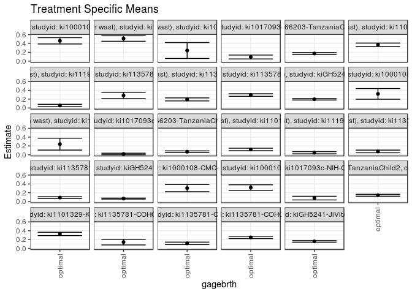

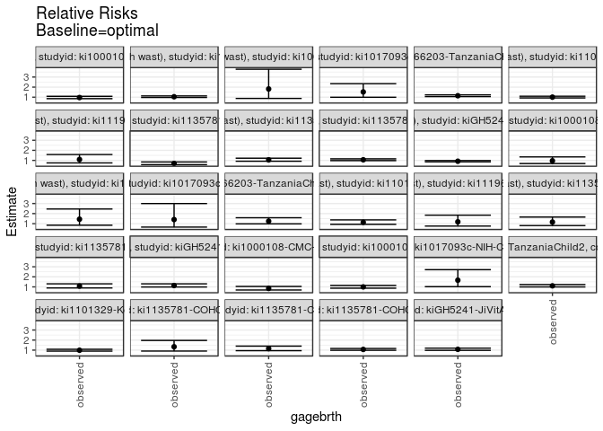

## Results Table

### Parameter: TSM

| agecat | studyid | country | intervention_level | baseline_level | estimate | ci_lower | ci_upper |
| --- | --- | --- | --- | --- | --- | --- | --- |
| 0-24 months (no birth wast) | ki1000108-CMC-V-BCS-2002 | INDIA | optimal | NA | 0.4601636 | 0.3887776 | 0.5315497 |
| 0-24 months (no birth wast) | ki1000108-IRC | INDIA | optimal | NA | 0.5126921 | 0.4502740 | 0.5751101 |
| 0-24 months (no birth wast) | ki1000109-EE | PAKISTAN | optimal | NA | 0.2408829 | 0.0605806 | 0.4211852 |
| 0-24 months (no birth wast) | ki1017093c-NIH-Crypto | BANGLADESH | optimal | NA | 0.0940781 | 0.0503003 | 0.1378559 |
| 0-24 months (no birth wast) | ki1066203-TanzaniaChild2 | TANZANIA, UNITED REPUBLIC OF | optimal | NA | 0.1730216 | 0.1530779 | 0.1929652 |
| 0-24 months (no birth wast) | ki1101329-Keneba | GAMBIA | optimal | NA | 0.3707332 | 0.3321018 | 0.4093646 |
| 0-24 months (no birth wast) | ki1119695-PROBIT | BELARUS | optimal | NA | 0.0561119 | 0.0293789 | 0.0828449 |
| 0-24 months (no birth wast) | ki1135781-COHORTS | GUATEMALA | optimal | NA | 0.2833417 | 0.2109028 | 0.3557805 |
| 0-24 months (no birth wast) | ki1135781-COHORTS | INDIA | optimal | NA | 0.1937769 | 0.1597740 | 0.2277799 |
| 0-24 months (no birth wast) | ki1135781-COHORTS | PHILIPPINES | optimal | NA | 0.2928768 | 0.2638102 | 0.3219433 |
| 0-24 months (no birth wast) | kiGH5241-JiVitA-3 | BANGLADESH | optimal | NA | 0.1966289 | 0.1802558 | 0.2130021 |
| 0-6 months (no birth wast) | ki1000108-CMC-V-BCS-2002 | INDIA | optimal | NA | 0.3188750 | 0.1980289 | 0.4397211 |
| 0-6 months (no birth wast) | ki1000108-IRC | INDIA | optimal | NA | 0.2410050 | 0.1068048 | 0.3752052 |
| 0-6 months (no birth wast) | ki1017093c-NIH-Crypto | BANGLADESH | optimal | NA | 0.0190061 | 0.0023648 | 0.0356473 |
| 0-6 months (no birth wast) | ki1066203-TanzaniaChild2 | TANZANIA, UNITED REPUBLIC OF | optimal | NA | 0.0688858 | 0.0496649 | 0.0881067 |
| 0-6 months (no birth wast) | ki1101329-Keneba | GAMBIA | optimal | NA | 0.1206620 | 0.0927669 | 0.1485571 |
| 0-6 months (no birth wast) | ki1119695-PROBIT | BELARUS | optimal | NA | 0.0464961 | 0.0220084 | 0.0709838 |
| 0-6 months (no birth wast) | ki1135781-COHORTS | INDIA | optimal | NA | 0.0758605 | 0.0456750 | 0.1060459 |
| 0-6 months (no birth wast) | ki1135781-COHORTS | PHILIPPINES | optimal | NA | 0.0903107 | 0.0702198 | 0.1104015 |
| 0-6 months (no birth wast) | kiGH5241-JiVitA-3 | BANGLADESH | optimal | NA | 0.0683773 | 0.0572176 | 0.0795371 |
| 6-24 months | ki1000108-CMC-V-BCS-2002 | INDIA | optimal | NA | 0.3047963 | 0.2237948 | 0.3857978 |
| 6-24 months | ki1000108-IRC | INDIA | optimal | NA | 0.3177829 | 0.2548014 | 0.3807645 |
| 6-24 months | ki1017093c-NIH-Crypto | BANGLADESH | optimal | NA | 0.0789850 | 0.0374647 | 0.1205054 |
| 6-24 months | ki1066203-TanzaniaChild2 | TANZANIA, UNITED REPUBLIC OF | optimal | NA | 0.1438015 | 0.1222383 | 0.1653646 |
| 6-24 months | ki1101329-Keneba | GAMBIA | optimal | NA | 0.3281112 | 0.2906150 | 0.3656075 |
| 6-24 months | ki1135781-COHORTS | GUATEMALA | optimal | NA | 0.1431786 | 0.0789388 | 0.2074185 |
| 6-24 months | ki1135781-COHORTS | INDIA | optimal | NA | 0.1145017 | 0.0865458 | 0.1424575 |
| 6-24 months | ki1135781-COHORTS | PHILIPPINES | optimal | NA | 0.2491967 | 0.2229116 | 0.2754819 |
| 6-24 months | kiGH5241-JiVitA-3 | BANGLADESH | optimal | NA | 0.1586954 | 0.1405233 | 0.1768675 |

### Parameter: E(Y)

| agecat | studyid | country | intervention_level | baseline_level | estimate | ci_lower | ci_upper |
| --- | --- | --- | --- | --- | --- | --- | --- |
| 0-24 months (no birth wast) | ki1000108-CMC-V-BCS-2002 | INDIA | observed | NA | 0.4425287 | 0.3902692 | 0.4947882 |
| 0-24 months (no birth wast) | ki1000108-IRC | INDIA | observed | NA | 0.5347044 | 0.4850733 | 0.5843354 |
| 0-24 months (no birth wast) | ki1000109-EE | PAKISTAN | observed | NA | 0.4376658 | 0.3875213 | 0.4878102 |
| 0-24 months (no birth wast) | ki1017093c-NIH-Crypto | BANGLADESH | observed | NA | 0.1432361 | 0.1182149 | 0.1682572 |
| 0-24 months (no birth wast) | ki1066203-TanzaniaChild2 | TANZANIA, UNITED REPUBLIC OF | observed | NA | 0.1975914 | 0.1811057 | 0.2140772 |
| 0-24 months (no birth wast) | ki1101329-Keneba | GAMBIA | observed | NA | 0.3725606 | 0.3495097 | 0.3956116 |
| 0-24 months (no birth wast) | ki1119695-PROBIT | BELARUS | observed | NA | 0.0612597 | 0.0474556 | 0.0750638 |
| 0-24 months (no birth wast) | ki1135781-COHORTS | GUATEMALA | observed | NA | 0.1984536 | 0.1587174 | 0.2381898 |
| 0-24 months (no birth wast) | ki1135781-COHORTS | INDIA | observed | NA | 0.2049180 | 0.1833143 | 0.2265218 |
| 0-24 months (no birth wast) | ki1135781-COHORTS | PHILIPPINES | observed | NA | 0.3113629 | 0.2945446 | 0.3281811 |
| 0-24 months (no birth wast) | kiGH5241-JiVitA-3 | BANGLADESH | observed | NA | 0.1807502 | 0.1716556 | 0.1898448 |
| 0-6 months (no birth wast) | ki1000108-CMC-V-BCS-2002 | INDIA | observed | NA | 0.3072289 | 0.2575285 | 0.3569293 |
| 0-6 months (no birth wast) | ki1000108-IRC | INDIA | observed | NA | 0.3477089 | 0.2991827 | 0.3962350 |
| 0-6 months (no birth wast) | ki1017093c-NIH-Crypto | BANGLADESH | observed | NA | 0.0267023 | 0.0151493 | 0.0382553 |
| 0-6 months (no birth wast) | ki1066203-TanzaniaChild2 | TANZANIA, UNITED REPUBLIC OF | observed | NA | 0.0859445 | 0.0743193 | 0.0975697 |
| 0-6 months (no birth wast) | ki1101329-Keneba | GAMBIA | observed | NA | 0.1367742 | 0.1196627 | 0.1538856 |
| 0-6 months (no birth wast) | ki1119695-PROBIT | BELARUS | observed | NA | 0.0550194 | 0.0412334 | 0.0688054 |
| 0-6 months (no birth wast) | ki1135781-COHORTS | INDIA | observed | NA | 0.0878763 | 0.0720416 | 0.1037111 |
| 0-6 months (no birth wast) | ki1135781-COHORTS | PHILIPPINES | observed | NA | 0.0975610 | 0.0867035 | 0.1084185 |
| 0-6 months (no birth wast) | kiGH5241-JiVitA-3 | BANGLADESH | observed | NA | 0.0776203 | 0.0714558 | 0.0837849 |
| 6-24 months | ki1000108-CMC-V-BCS-2002 | INDIA | observed | NA | 0.2592593 | 0.2133485 | 0.3051700 |
| 6-24 months | ki1000108-IRC | INDIA | observed | NA | 0.3179487 | 0.2716722 | 0.3642252 |
| 6-24 months | ki1017093c-NIH-Crypto | BANGLADESH | observed | NA | 0.1315068 | 0.1069744 | 0.1560393 |
| 6-24 months | ki1066203-TanzaniaChild2 | TANZANIA, UNITED REPUBLIC OF | observed | NA | 0.1591987 | 0.1427306 | 0.1756669 |
| 6-24 months | ki1101329-Keneba | GAMBIA | observed | NA | 0.3247706 | 0.3020649 | 0.3474764 |
| 6-24 months | ki1135781-COHORTS | GUATEMALA | observed | NA | 0.1914894 | 0.1516651 | 0.2313136 |
| 6-24 months | ki1135781-COHORTS | INDIA | observed | NA | 0.1318764 | 0.1136647 | 0.1500881 |
| 6-24 months | ki1135781-COHORTS | PHILIPPINES | observed | NA | 0.2669537 | 0.2505274 | 0.2833801 |
| 6-24 months | kiGH5241-JiVitA-3 | BANGLADESH | observed | NA | 0.1716523 | 0.1610413 | 0.1822634 |

### Parameter: RR

| agecat | studyid | country | intervention_level | baseline_level | estimate | ci_lower | ci_upper |
| --- | --- | --- | --- | --- | --- | --- | --- |
| 0-24 months (no birth wast) | ki1000108-CMC-V-BCS-2002 | INDIA | observed | optimal | 0.9616769 | 0.8527799 | 1.0844797 |
| 0-24 months (no birth wast) | ki1000108-IRC | INDIA | observed | optimal | 1.0429348 | 0.9692048 | 1.1222736 |
| 0-24 months (no birth wast) | ki1000109-EE | PAKISTAN | observed | optimal | 1.8169237 | 0.8740599 | 3.7768712 |
| 0-24 months (no birth wast) | ki1017093c-NIH-Crypto | BANGLADESH | observed | optimal | 1.5225232 | 0.9924983 | 2.3355979 |
| 0-24 months (no birth wast) | ki1066203-TanzaniaChild2 | TANZANIA, UNITED REPUBLIC OF | observed | optimal | 1.1420047 | 1.0578803 | 1.2328188 |
| 0-24 months (no birth wast) | ki1101329-Keneba | GAMBIA | observed | optimal | 1.0049292 | 0.9239141 | 1.0930483 |
| 0-24 months (no birth wast) | ki1119695-PROBIT | BELARUS | observed | optimal | 1.0917417 | 0.7514909 | 1.5860470 |
| 0-24 months (no birth wast) | ki1135781-COHORTS | GUATEMALA | observed | optimal | 0.7004039 | 0.5779109 | 0.8488604 |
| 0-24 months (no birth wast) | ki1135781-COHORTS | INDIA | observed | optimal | 1.0574944 | 0.9171715 | 1.2192861 |
| 0-24 months (no birth wast) | ki1135781-COHORTS | PHILIPPINES | observed | optimal | 1.0631191 | 0.9806422 | 1.1525326 |
| 0-24 months (no birth wast) | kiGH5241-JiVitA-3 | BANGLADESH | observed | optimal | 0.9192452 | 0.8602191 | 0.9823216 |
| 0-6 months (no birth wast) | ki1000108-CMC-V-BCS-2002 | INDIA | observed | optimal | 0.9634776 | 0.6898018 | 1.3457331 |
| 0-6 months (no birth wast) | ki1000108-IRC | INDIA | observed | optimal | 1.4427455 | 0.8469898 | 2.4575439 |
| 0-6 months (no birth wast) | ki1017093c-NIH-Crypto | BANGLADESH | observed | optimal | 1.4049339 | 0.6587086 | 2.9965286 |
| 0-6 months (no birth wast) | ki1066203-TanzaniaChild2 | TANZANIA, UNITED REPUBLIC OF | observed | optimal | 1.2476374 | 0.9813198 | 1.5862303 |
| 0-6 months (no birth wast) | ki1101329-Keneba | GAMBIA | observed | optimal | 1.1335315 | 0.9368463 | 1.3715097 |
| 0-6 months (no birth wast) | ki1119695-PROBIT | BELARUS | observed | optimal | 1.1833124 | 0.7598481 | 1.8427738 |
| 0-6 months (no birth wast) | ki1135781-COHORTS | INDIA | observed | optimal | 1.1583941 | 0.8101737 | 1.6562831 |
| 0-6 months (no birth wast) | ki1135781-COHORTS | PHILIPPINES | observed | optimal | 1.0802818 | 0.8939301 | 1.3054811 |
| 0-6 months (no birth wast) | kiGH5241-JiVitA-3 | BANGLADESH | observed | optimal | 1.1351763 | 0.9890700 | 1.3028656 |
| 6-24 months | ki1000108-CMC-V-BCS-2002 | INDIA | observed | optimal | 0.8505985 | 0.6918522 | 1.0457694 |
| 6-24 months | ki1000108-IRC | INDIA | observed | optimal | 1.0005217 | 0.8729564 | 1.1467282 |
| 6-24 months | ki1017093c-NIH-Crypto | BANGLADESH | observed | optimal | 1.6649597 | 1.0224600 | 2.7111974 |
| 6-24 months | ki1066203-TanzaniaChild2 | TANZANIA, UNITED REPUBLIC OF | observed | optimal | 1.1070731 | 0.9956971 | 1.2309074 |
| 6-24 months | ki1101329-Keneba | GAMBIA | observed | optimal | 0.9898188 | 0.9043835 | 1.0833249 |
| 6-24 months | ki1135781-COHORTS | GUATEMALA | observed | optimal | 1.3374158 | 0.9104066 | 1.9647058 |
| 6-24 months | ki1135781-COHORTS | INDIA | observed | optimal | 1.1517424 | 0.9471918 | 1.4004668 |
| 6-24 months | ki1135781-COHORTS | PHILIPPINES | observed | optimal | 1.0712569 | 0.9848327 | 1.1652653 |
| 6-24 months | kiGH5241-JiVitA-3 | BANGLADESH | observed | optimal | 1.0816463 | 0.9791847 | 1.1948294 |

### Parameter: PAR

| agecat | studyid | country | intervention_level | baseline_level | estimate | ci_lower | ci_upper |
| --- | --- | --- | --- | --- | --- | --- | --- |
| 0-24 months (no birth wast) | ki1000108-CMC-V-BCS-2002 | INDIA | optimal | NA | -0.0176349 | -0.0726573 | 0.0373876 |
| 0-24 months (no birth wast) | ki1000108-IRC | INDIA | optimal | NA | 0.0220123 | -0.0155079 | 0.0595326 |
| 0-24 months (no birth wast) | ki1000109-EE | PAKISTAN | optimal | NA | 0.1967829 | 0.0206445 | 0.3729213 |
| 0-24 months (no birth wast) | ki1017093c-NIH-Crypto | BANGLADESH | optimal | NA | 0.0491580 | 0.0081610 | 0.0901550 |
| 0-24 months (no birth wast) | ki1066203-TanzaniaChild2 | TANZANIA, UNITED REPUBLIC OF | optimal | NA | 0.0245699 | 0.0112477 | 0.0378921 |
| 0-24 months (no birth wast) | ki1101329-Keneba | GAMBIA | optimal | NA | 0.0018274 | -0.0293345 | 0.0329894 |
| 0-24 months (no birth wast) | ki1119695-PROBIT | BELARUS | optimal | NA | 0.0051478 | -0.0155862 | 0.0258818 |
| 0-24 months (no birth wast) | ki1135781-COHORTS | GUATEMALA | optimal | NA | -0.0848880 | -0.1394288 | -0.0303473 |
| 0-24 months (no birth wast) | ki1135781-COHORTS | INDIA | optimal | NA | 0.0111411 | -0.0164937 | 0.0387759 |
| 0-24 months (no birth wast) | ki1135781-COHORTS | PHILIPPINES | optimal | NA | 0.0184861 | -0.0051391 | 0.0421113 |
| 0-24 months (no birth wast) | kiGH5241-JiVitA-3 | BANGLADESH | optimal | NA | -0.0158787 | -0.0289523 | -0.0028051 |
| 0-6 months (no birth wast) | ki1000108-CMC-V-BCS-2002 | INDIA | optimal | NA | -0.0116461 | -0.1183142 | 0.0950221 |
| 0-6 months (no birth wast) | ki1000108-IRC | INDIA | optimal | NA | 0.1067039 | -0.0218303 | 0.2352381 |
| 0-6 months (no birth wast) | ki1017093c-NIH-Crypto | BANGLADESH | optimal | NA | 0.0076962 | -0.0070521 | 0.0224445 |
| 0-6 months (no birth wast) | ki1066203-TanzaniaChild2 | TANZANIA, UNITED REPUBLIC OF | optimal | NA | 0.0170587 | 0.0004257 | 0.0336917 |
| 0-6 months (no birth wast) | ki1101329-Keneba | GAMBIA | optimal | NA | 0.0161122 | -0.0069088 | 0.0391332 |
| 0-6 months (no birth wast) | ki1119695-PROBIT | BELARUS | optimal | NA | 0.0085233 | -0.0120061 | 0.0290527 |
| 0-6 months (no birth wast) | ki1135781-COHORTS | INDIA | optimal | NA | 0.0120159 | -0.0152268 | 0.0392585 |
| 0-6 months (no birth wast) | ki1135781-COHORTS | PHILIPPINES | optimal | NA | 0.0072503 | -0.0098451 | 0.0243457 |
| 0-6 months (no birth wast) | kiGH5241-JiVitA-3 | BANGLADESH | optimal | NA | 0.0092430 | -0.0001613 | 0.0186473 |
| 6-24 months | ki1000108-CMC-V-BCS-2002 | INDIA | optimal | NA | -0.0455370 | -0.1086393 | 0.0175653 |
| 6-24 months | ki1000108-IRC | INDIA | optimal | NA | 0.0001658 | -0.0431773 | 0.0435089 |
| 6-24 months | ki1017093c-NIH-Crypto | BANGLADESH | optimal | NA | 0.0525218 | 0.0129810 | 0.0920626 |
| 6-24 months | ki1066203-TanzaniaChild2 | TANZANIA, UNITED REPUBLIC OF | optimal | NA | 0.0153973 | 0.0001060 | 0.0306886 |
| 6-24 months | ki1101329-Keneba | GAMBIA | optimal | NA | -0.0033406 | -0.0329600 | 0.0262788 |
| 6-24 months | ki1135781-COHORTS | GUATEMALA | optimal | NA | 0.0483107 | -0.0070357 | 0.1036572 |
| 6-24 months | ki1135781-COHORTS | INDIA | optimal | NA | 0.0173748 | -0.0050397 | 0.0397893 |
| 6-24 months | ki1135781-COHORTS | PHILIPPINES | optimal | NA | 0.0177570 | -0.0032051 | 0.0387190 |
| 6-24 months | kiGH5241-JiVitA-3 | BANGLADESH | optimal | NA | 0.0129569 | -0.0028964 | 0.0288102 |

### Parameter: PAF

| agecat | studyid | country | intervention_level | baseline_level | estimate | ci_lower | ci_upper |
| --- | --- | --- | --- | --- | --- | --- | --- |
| 0-24 months (no birth wast) | ki1000108-CMC-V-BCS-2002 | INDIA | optimal | NA | -0.0398503 | -0.1726355 | 0.0778988 |
| 0-24 months (no birth wast) | ki1000108-IRC | INDIA | optimal | NA | 0.0411673 | -0.0317737 | 0.1089517 |
| 0-24 months (no birth wast) | ki1000109-EE | PAKISTAN | optimal | NA | 0.4496191 | -0.1440864 | 0.7352306 |
| 0-24 months (no birth wast) | ki1017093c-NIH-Crypto | BANGLADESH | optimal | NA | 0.3431956 | -0.0075584 | 0.5718441 |
| 0-24 months (no birth wast) | ki1066203-TanzaniaChild2 | TANZANIA, UNITED REPUBLIC OF | optimal | NA | 0.1243469 | 0.0547135 | 0.1888508 |
| 0-24 months (no birth wast) | ki1101329-Keneba | GAMBIA | optimal | NA | 0.0049051 | -0.0823517 | 0.0851274 |
| 0-24 months (no birth wast) | ki1119695-PROBIT | BELARUS | optimal | NA | 0.0840324 | -0.3306882 | 0.3695017 |
| 0-24 months (no birth wast) | ki1135781-COHORTS | GUATEMALA | optimal | NA | -0.4277475 | -0.7303705 | -0.1780500 |
| 0-24 months (no birth wast) | ki1135781-COHORTS | INDIA | optimal | NA | 0.0543686 | -0.0903086 | 0.1798479 |
| 0-24 months (no birth wast) | ki1135781-COHORTS | PHILIPPINES | optimal | NA | 0.0593716 | -0.0197399 | 0.1323456 |
| 0-24 months (no birth wast) | kiGH5241-JiVitA-3 | BANGLADESH | optimal | NA | -0.0878490 | -0.1624945 | -0.0179966 |
| 0-6 months (no birth wast) | ki1000108-CMC-V-BCS-2002 | INDIA | optimal | NA | -0.0379069 | -0.4496918 | 0.2569106 |
| 0-6 months (no birth wast) | ki1000108-IRC | INDIA | optimal | NA | 0.3068771 | -0.1806517 | 0.5930897 |
| 0-6 months (no birth wast) | ki1017093c-NIH-Crypto | BANGLADESH | optimal | NA | 0.2882227 | -0.5181220 | 0.6662805 |
| 0-6 months (no birth wast) | ki1066203-TanzaniaChild2 | TANZANIA, UNITED REPUBLIC OF | optimal | NA | 0.1984851 | -0.0190358 | 0.3695745 |
| 0-6 months (no birth wast) | ki1101329-Keneba | GAMBIA | optimal | NA | 0.1178013 | -0.0674110 | 0.2708765 |
| 0-6 months (no birth wast) | ki1119695-PROBIT | BELARUS | optimal | NA | 0.1549146 | -0.3160524 | 0.4573398 |
| 0-6 months (no birth wast) | ki1135781-COHORTS | INDIA | optimal | NA | 0.1367360 | -0.2343033 | 0.3962385 |
| 0-6 months (no birth wast) | ki1135781-COHORTS | PHILIPPINES | optimal | NA | 0.0743156 | -0.1186557 | 0.2339989 |
| 0-6 months (no birth wast) | kiGH5241-JiVitA-3 | BANGLADESH | optimal | NA | 0.1190796 | -0.0110508 | 0.2324611 |
| 6-24 months | ki1000108-CMC-V-BCS-2002 | INDIA | optimal | NA | -0.1756428 | -0.4453954 | 0.0437662 |
| 6-24 months | ki1000108-IRC | INDIA | optimal | NA | 0.0005214 | -0.1455326 | 0.1279537 |
| 6-24 months | ki1017093c-NIH-Crypto | BANGLADESH | optimal | NA | 0.3993849 | 0.0219666 | 0.6311593 |
| 6-24 months | ki1066203-TanzaniaChild2 | TANZANIA, UNITED REPUBLIC OF | optimal | NA | 0.0967173 | -0.0043215 | 0.1875912 |
| 6-24 months | ki1101329-Keneba | GAMBIA | optimal | NA | -0.0102860 | -0.1057256 | 0.0769159 |
| 6-24 months | ki1135781-COHORTS | GUATEMALA | optimal | NA | 0.2522894 | -0.0984103 | 0.4910179 |
| 6-24 months | ki1135781-COHORTS | INDIA | optimal | NA | 0.1317503 | -0.0557524 | 0.2859524 |
| 6-24 months | ki1135781-COHORTS | PHILIPPINES | optimal | NA | 0.0665171 | -0.0154009 | 0.1418263 |
| 6-24 months | kiGH5241-JiVitA-3 | BANGLADESH | optimal | NA | 0.0754834 | -0.0212577 | 0.1630605 |